# LERU-exchange statistics

Published

June 2, 2026

# Summary

This report reviews the application rounds of 2024 and 2025 as well as the ongoing 2026 application round of the LERU Law PhD Exchange Programme. With this review we want to clarify the scope and functioning of the exchange programme as well as the role and workload for the coordinators. We summarise where the applicants come from, their preferences, the outcomes of the allocation process (from initial allocation to finale outcome), compare this with the number of availabe positions, and finally analyse the relation between home universities and destinations.

## Improvements and current situation

After the 2025 application round, the high number of unresolved application was flagged as the main issue. As this was at least in part due to the process overlapping with the Summmer break, we moved the deadline forward to the 4 May 2026.

- **4 May 2026:** 51 were submitted (compared to 75 in 2024 and 80 in 2025).
- **20 May 2026:** 46 applications assigned to destinations and 5 remain provisionally unassigned.
- **02 June 2026:** 19 (37.3%) applications accepted.

In view of the current status, we expect that that we will be able to complete processing of applications before the Summer-break. Applications that are allocated, but for which no final or provisional decision is received, will be closed.

## Overview of the time investment of coordinators

On a yearly basis, the estimated time-investment consists in:

1. A fixed part to prepare the yearly application round. This includes collecting information from all the partners, updating the website, and distributing the call-materials to all partners. This is estimated at **2 working days**.
2. A variable part that depends on the number of applicants. This is estimated at **30 minutes per applicant**, and includes:
   - Downloading and reorganising the application materials
   - Checking each application
   - Running and fine-tuning the distribution
   - Handing over the applications to the different partners (staff at participating faculties can consult the applications online, but they each receive an email with an update)
   - Processing acceptances and informing candidates
   - Ad hox inquiries, trouble shooting, and sending reminders to partners and candidates.
3. A variable part for platform maintenance and improvements, extensive work on the website, and communication and reporting on the exchange scheme at LERU-meetings. This is estimated at **5 working days**.

Based on the historical figure of 80 applicants, this leads to an overall estimate of **12 working days per year**.

The initial time-investment (mainly between 2022 and 2024) for the development of the online application platform is not taken into account in this yearly overview. Time spent on the development and refinement of the application platform is estimated at **40 working days**.

## Overview of the data

- **the applications:** how many applications are there and what are their home universities?
- **the preferences of the applicants:** which destinations do they list as their first, second and third preference?
- **the results of each application round:** how are candidates matched to their preferences, how many of them are accepted, and how does this compare to the number of positions that are available in theory?
- **the relations between home universities and destinations:** where do candidates come from and where do they go?

**A note about the data:** the data used in this report are based on the information accessible to the coordinators. This included the information stored on the application platform as well as the Excel-sheets we use to keep track of all applications. These data may not reflect the reality in at least two ways. Acceptances that are communicated directly to the candidates, but not to the coordinators remain invisible. Conversely, visits that are cancelled after acceptance migth not always be registered either.

# Applications

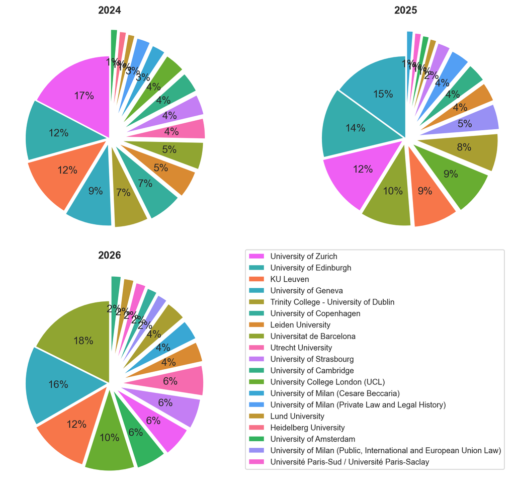

Figure 1: Applications by year and home university

Table 1: Applications by year and home university

| Home university | 2024 | 2025 | 2026 |
| --- | --- | --- | --- |
| University of Geneva | 7 | 12 | 8 |
| University of Zurich | 13 | 10 | 3 |
| KU Leuven | 9 | 7 | 6 |
| Universitat de Barcelona | 4 | 8 | 9 |
| University of Edinburgh | 9 | 11 | 0 |
| University College London (UCL) | 3 | 7 | 5 |
| Trinity College - University of Dublin | 5 | 6 | 2 |
| Leiden University | 4 | 3 | 2 |
| University of Strasbourg | 3 | 2 | 3 |
| University of Cambridge | 3 | 3 | 1 |
| University of Copenhagen | 5 | 0 | 1 |
| Utrecht University | 3 | 0 | 3 |
| University of Milan (Cesare Beccaria) | 2 | 1 | 2 |
| University of Milan (Private Law and Legal History) | 2 | 3 | 0 |
| University of Milan (Public, International and European Union Law) | 0 | 4 | 1 |
| University of Amsterdam | 1 | 1 | 3 |
| Lund University | 1 | 1 | 1 |
| Université Paris-Sud / Université Paris-Saclay | 0 | 1 | 1 |
| Heidelberg University | 1 | 0 | 0 |

# Preferences

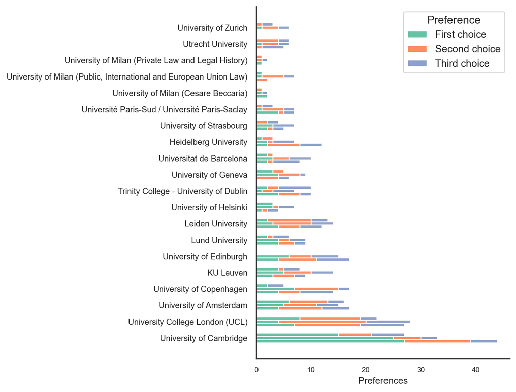

Figure 2: Preferences by year and destination

Table 2: Preferences by year and destination

|  | 2024 First choice | 2024 Second choice | 2024 Third choice | 2025 First choice | 2025 Second choice | 2025 Third choice | 2026 First choice | 2026 Second choice | 2026 Third choice |
| --- | --- | --- | --- | --- | --- | --- | --- | --- | --- |
| University of Cambridge | 27 | 12 | 5 | 25 | 5 | 3 | 15 | 6 | 6 |
| University College London (UCL) | 7 | 12 | 8 | 4 | 16 | 8 | 8 | 11 | 3 |
| University of Amsterdam | 4 | 8 | 5 | 5 | 6 | 4 | 6 | 7 | 3 |
| University of Copenhagen | 4 | 4 | 6 | 7 | 8 | 2 | 2 | 0 | 3 |
| KU Leuven | 3 | 4 | 2 | 5 | 5 | 4 | 4 | 1 | 3 |
| University of Edinburgh | 4 | 7 | 6 | 6 | 4 | 5 | 0 | 0 | 0 |
| Lund University | 4 | 3 | 2 | 4 | 2 | 3 | 2 | 1 | 3 |
| Leiden University | 4 | 4 | 4 | 3 | 7 | 4 | 2 | 8 | 3 |
| University of Helsinki | 1 | 1 | 2 | 3 | 1 | 3 | 3 | 0 | 0 |
| Trinity College - University of Dublin | 4 | 4 | 2 | 1 | 2 | 4 | 2 | 2 | 6 |
| University of Geneva | 0 | 4 | 2 | 4 | 4 | 1 | 3 | 2 | 0 |
| Universitat de Barcelona | 2 | 1 | 5 | 3 | 3 | 4 | 2 | 1 | 0 |
| Heidelberg University | 2 | 6 | 4 | 2 | 1 | 4 | 1 | 2 | 0 |
| University of Strasbourg | 2 | 1 | 2 | 3 | 0 | 4 | 0 | 2 | 2 |
| Université Paris-Sud / Université Paris-Saclay | 4 | 1 | 2 | 1 | 4 | 2 | 0 | 1 | 2 |
| University of Milan (Cesare Beccaria) | 2 | 0 | 0 | 1 | 0 | 1 | 0 | 1 | 0 |
| University of Milan (Public, International and European Union Law) | 0 | 2 | 0 | 1 | 4 | 2 | 1 | 0 | 0 |
| University of Milan (Private Law and Legal History) | 1 | 0 | 0 | 0 | 1 | 1 | 0 | 1 | 0 |
| Utrecht University | 0 | 1 | 4 | 1 | 3 | 2 | 0 | 4 | 2 |
| University of Zurich | 0 | 0 | 0 | 1 | 3 | 2 | 0 | 1 | 2 |

# Assignments and acceptances

## Assignments

We first examine at the assignments without taking into account whether candidates whose application is transferred to a destination is actually accepted. At the aggregated level (Figure 3), we see a high share of allocations to first and second preferences. Moreover, the number of not assigned candidates remains low. This suggests that, at least in theory, we succeed rather well in matching offer and demand.There are no indications that a further decrease of the number of not assigned candidates is desirable. Some applicants are interested in an alternative opportunity (a fourth preference), but this remains exceptional (claim based on communications with the candidates).

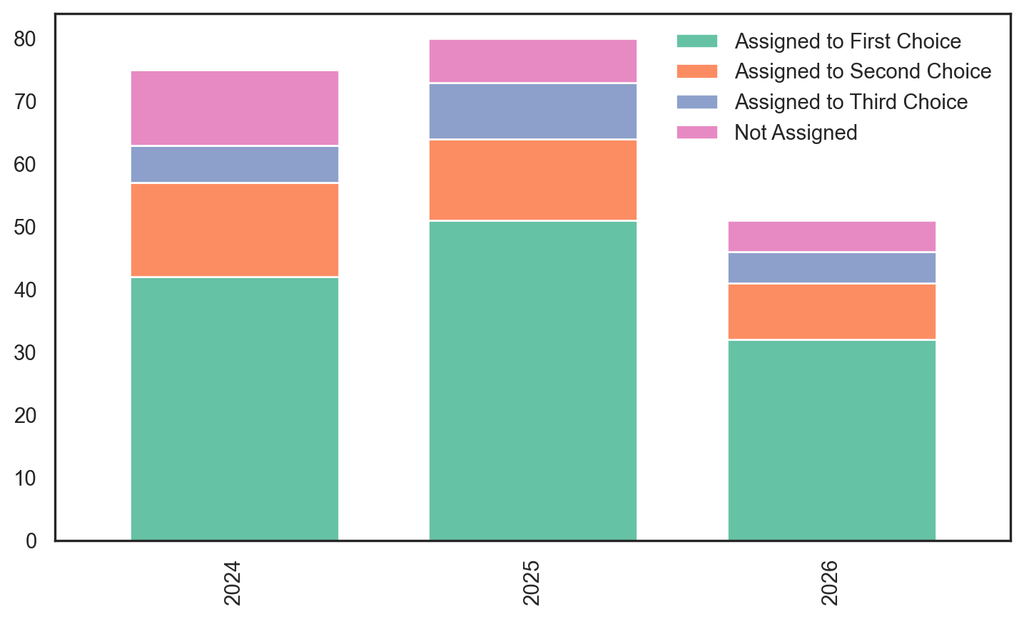

Figure 3: Assignments by year and preference

The unaggregated data in Table 3 (separating the applicants of each home university) also confirm that there are no substantial discrepancies across universities. Applicants from all home universities have a high chance of being assigned to their first or second preferences.

Table 3: Assignments by year and home university

|  | 2024 Assigned to First Choice | 2024 Assigned to Second Choice | 2024 Assigned to Third Choice | 2024 NotAssigned | 2024 Applications | 2025 Assigned to First Choice | 2025 Assigned to Second Choice | 2025 Assigned to Third Choice | 2025 NotAssigned | 2025 Applications | 2026 Assigned to First Choice | 2026 Assigned to Second Choice | 2026 Assigned to Third Choice | 2026 NotAssigned | 2026 Applications |
| --- | --- | --- | --- | --- | --- | --- | --- | --- | --- | --- | --- | --- | --- | --- | --- |
| University of Zurich | 9 | 1 | 1 | 2 | 13 | 8 | 1 | 1 | 0 | 10 | 1 | 0 | 1 | 1 | 3 |
| University of Edinburgh | 6 | 2 | 1 | 0 | 9 | 8 | 2 | 0 | 1 | 11 | 0 | 0 | 0 | 0 | 0 |
| University of Geneva | 5 | 1 | 0 | 1 | 7 | 8 | 2 | 1 | 1 | 12 | 3 | 1 | 1 | 3 | 8 |
| KU Leuven | 4 | 2 | 1 | 2 | 9 | 5 | 2 | 0 | 0 | 7 | 2 | 3 | 1 | 0 | 6 |
| Universitat de Barcelona | 3 | 0 | 1 | 0 | 4 | 5 | 2 | 0 | 1 | 8 | 8 | 1 | 0 | 0 | 9 |
| University College London (UCL) | 3 | 0 | 0 | 0 | 3 | 6 | 1 | 0 | 0 | 7 | 4 | 1 | 0 | 0 | 5 |
| University of Cambridge | 2 | 0 | 0 | 1 | 3 | 1 | 1 | 0 | 1 | 3 | 1 | 0 | 0 | 0 | 1 |
| Utrecht University | 2 | 1 | 0 | 0 | 3 | 0 | 0 | 0 | 0 | 0 | 1 | 2 | 0 | 0 | 3 |
| Leiden University | 2 | 0 | 0 | 2 | 4 | 2 | 0 | 0 | 1 | 3 | 2 | 0 | 0 | 0 | 2 |
| University of Copenhagen | 1 | 3 | 0 | 1 | 5 | 0 | 0 | 0 | 0 | 0 | 1 | 0 | 0 | 0 | 1 |
| Trinity College - University of Dublin | 1 | 3 | 0 | 1 | 5 | 3 | 0 | 2 | 1 | 6 | 1 | 0 | 1 | 0 | 2 |
| University of Milan (Cesare Beccaria) | 1 | 1 | 0 | 0 | 2 | 0 | 1 | 0 | 0 | 1 | 1 | 0 | 0 | 1 | 2 |
| University of Milan (Private Law and Legal History) | 1 | 0 | 0 | 1 | 2 | 1 | 0 | 2 | 0 | 3 | 0 | 0 | 0 | 0 | 0 |
| University of Strasbourg | 1 | 1 | 0 | 1 | 3 | 1 | 0 | 1 | 0 | 2 | 2 | 0 | 1 | 0 | 3 |
| Heidelberg University | 1 | 0 | 0 | 0 | 1 | 0 | 0 | 0 | 0 | 0 | 0 | 0 | 0 | 0 | 0 |
| University of Amsterdam | 0 | 0 | 1 | 0 | 1 | 0 | 0 | 0 | 1 | 1 | 3 | 0 | 0 | 0 | 3 |
| Lund University | 0 | 0 | 1 | 0 | 1 | 1 | 0 | 0 | 0 | 1 | 1 | 0 | 0 | 0 | 1 |
| University of Milan (Public, International and European Union Law) | 0 | 0 | 0 | 0 | 0 | 1 | 1 | 2 | 0 | 4 | 0 | 1 | 0 | 0 | 1 |
| Université Paris-Sud / Université Paris-Saclay | 0 | 0 | 0 | 0 | 0 | 1 | 0 | 0 | 0 | 1 | 1 | 0 | 0 | 0 | 1 |
| Total | 42 | 15 | 6 | 12 | 75 | 51 | 13 | 9 | 7 | 80 | 32 | 9 | 5 | 5 | 51 |

# Acceptances

When we examine what happens after the applications were distributed, we see that in practice we cannot make most of the theoretically available positions. Even though we can assign a large share of applicants to a potential destination, these assignments do not always lead to an effective acceptance. This happens in two situations. Some applicants cannot be accepted at the faculty or department they were assigned to. This is most often due to the fact that either the timing does not work out, because of a lack of fit, or because a suitable academic host is not available. In such cases applicants are either rejected or (if still possible)redirected to another potential destination. In many cases, however, no final decision reaches the coordinators.

The results for 2024 and 2025 in Table 4 and Figure 4 are final, whereas the results for 2026 capture the situation on 02 June 2026. We first look at the relation between preferences (first, second, third) and final results. Next, we refine this to reveal differences between destinations.

Table 4: Outcomes by year and outcome type

| Detailed status | 2024 | 2025 | 2026 |
| --- | --- | --- | --- |
| Accepted at first choice | 40 | 36 | 18 |
| Accepted at second choice | 12 | 7 | 1 |
| Accepted at third choice | 4 | 7 | 0 |
| Accepted at new choice | 0 | 1 | 0 |
| Assigned to first choice - unresolved | 1 | 13 | 14 |
| Assigned to second choice - unresolved | 3 | 4 | 7 |
| Assigned to third choice - unresolved | 2 | 2 | 3 |
| Not assigned, waitlisted - unresolved | 12 | 2 | 6 |
| Rejected | 0 | 8 | 2 |
| Withdrawn | 1 | 0 | 0 |

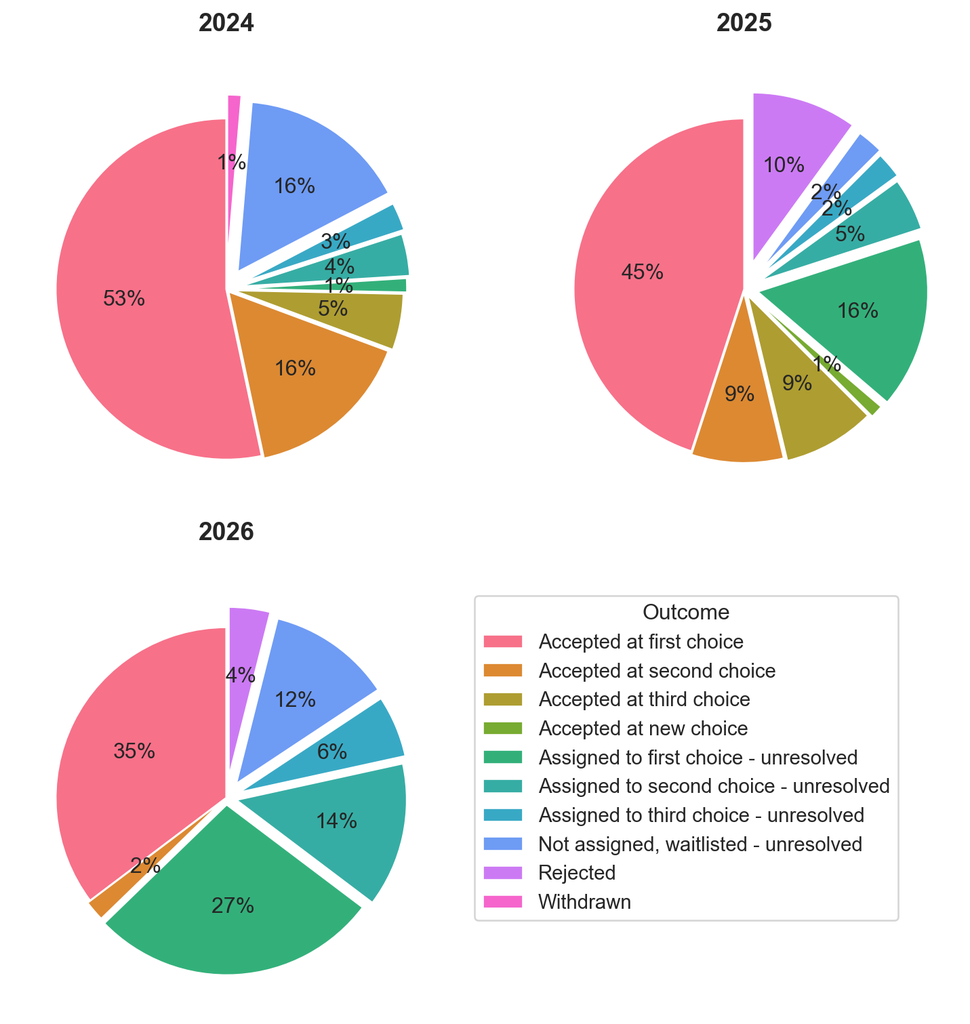

Figure 4: Outcomes by year and outcome type

How do assignments and acceptances then compare to the number of positions that are available at each participating faculty or department? Table 5 shows the number of applicants assigned to each destination, the resulting acceptances, and the percentage of the available positions that were effectively used. The total (theoretical) number of available positions was 101 (resp. 91 for 2026).

- In 2024 62% of the available positions were assigned to a candidate, and 55% were effectively filled.
- In 2025 73% of the available positions were assigned, and 50% were effectively filled.
- For 2026, currently 51% of the available positions have been assigned. Final results cannot yet be provided.

Table 5: Available positions used by year and by destination

| Assigned to | 2024 Assigned | 2024 Accepted | 2025 Assigned | 2025 Accepted | 2026 Assigned | 2026 Accepted | Available positions |
| --- | --- | --- | --- | --- | --- | --- | --- |
| Heidelberg University | 3 (100.0%) | 1 (33.33%) | 1 (33.33%) | 1 (33.33%) | 2 (66.67%) | 0 (0.0%) | 3 |
| KU Leuven | 5 (50.0%) | 5 (50.0%) | 8 (80.0%) | 1 (10.0%) | 5 (50.0%) | 1 (10.0%) | 10 |
| Leiden University | 6 (60.0%) | 6 (60.0%) | 6 (60.0%) | 4 (40.0%) | 7 (70.0%) | 0 (0.0%) | 10 |
| Lund University | 3 (75.0%) | 3 (75.0%) | 4 (100.0%) | 4 (100.0%) | 3 (75.0%) | 0 (0.0%) | 4 |
| Trinity College - University of Dublin | 4 (50.0%) | 4 (50.0%) | 2 (25.0%) | 2 (25.0%) | 5 (62.5%) | 2 (25.0%) | 8 |
| Universitat de Barcelona | 3 (75.0%) | 3 (75.0%) | 4 (100.0%) | 4 (100.0%) | 2 (50.0%) | 2 (50.0%) | 4 |
| University College London (UCL) | 5 (125.0%) | 4 (100.0%) | 4 (100.0%) | 4 (100.0%) | 4 (100.0%) | 3 (75.0%) | 4 |
| University of Amsterdam | 2 (100.0%) | 2 (100.0%) | 2 (100.0%) | 2 (100.0%) | 2 (100.0%) | 2 (100.0%) | 2 |
| University of Cambridge | 6 (100.0%) | 6 (100.0%) | 6 (100.0%) | 6 (100.0%) | 6 (100.0%) | 6 (100.0%) | 6 |
| University of Copenhagen | 4 (100.0%) | 4 (100.0%) | 4 (100.0%) | 1 (25.0%) | 2 (50.0%) | 0 (0.0%) | 4 |
| University of Edinburgh | 8 (80.0%) | 8 (80.0%) | 10 (100.0%) | 9 (90.0%) | 0 (0.0%) | 0 (0.0%) | 10 |
| University of Geneva | 3 (60.0%) | 0 (0.0%) | 5 (100.0%) | 0 (0.0%) | 3 (60.0%) | 0 (0.0%) | 5 |
| University of Helsinki | 2 (100.0%) | 2 (100.0%) | 2 (100.0%) | 2 (100.0%) | 2 (100.0%) | 2 (100.0%) | 2 |
| University of Milan (Cesare Beccaria) | 2 (100.0%) | 2 (100.0%) | 2 (100.0%) | 2 (100.0%) | 0 (0.0%) | 0 (0.0%) | 2 |
| University of Milan (Private Law and Legal History) | 1 (33.33%) | 1 (33.33%) | 1 (33.33%) | 1 (33.33%) | 0 (0.0%) | 0 (0.0%) | 3 |
| University of Milan (Public, International and European Union Law) | 0 (0.0%) | 0 (0.0%) | 2 (33.33%) | 2 (33.33%) | 1 (16.67%) | 1 (16.67%) | 6 |
| University of Strasbourg | 3 (50.0%) | 3 (50.0%) | 3 (50.0%) | 2 (33.33%) | 0 (0.0%) | 0 (0.0%) | 6 |
| University of Zurich | 0 (0.0%) | 0 (0.0%) | 3 (50.0%) | 3 (50.0%) | 0 (0.0%) | 0 (0.0%) | 6 |
| Université Paris-Sud / Université Paris-Saclay | 2 (50.0%) | 2 (50.0%) | 3 (75.0%) | 0 (0.0%) | 1 (25.0%) | 0 (0.0%) | 4 |
| Utrecht University | 1 (50.0%) | 0 (0.0%) | 2 (100.0%) | 1 (50.0%) | 1 (50.0%) | 0 (0.0%) | 2 |

# Home universities and destinations

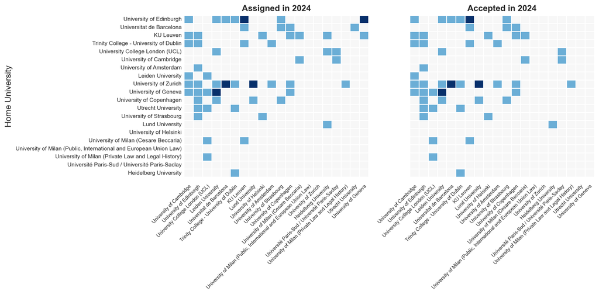

Figure 5: Home to destination flows in 2024

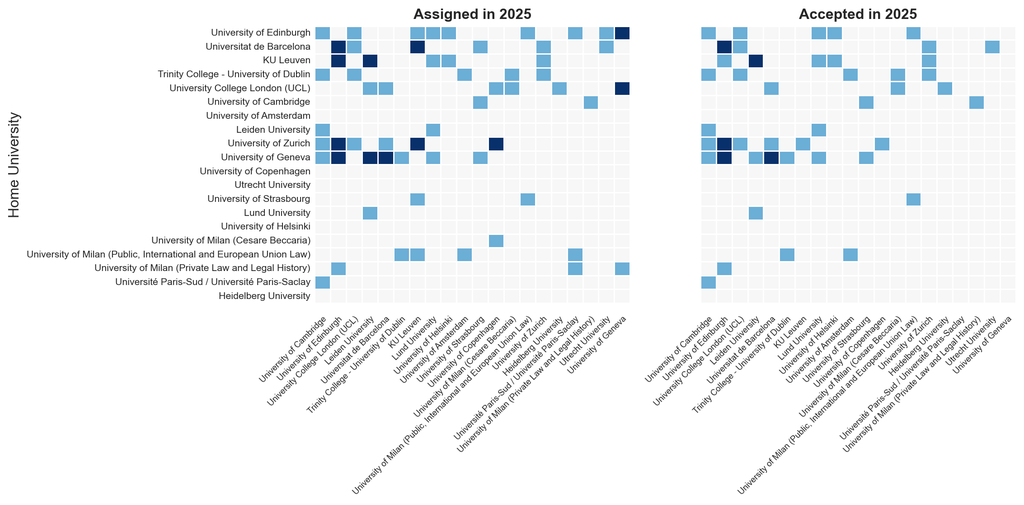

Figure 6: Home to destination flows in 2025

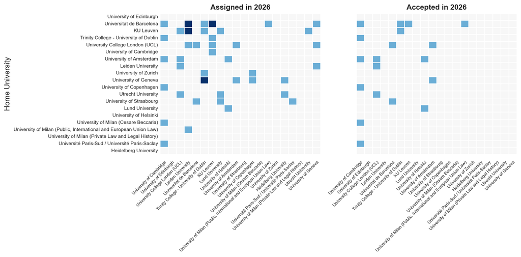

Figure 7: Home to destination flows in 2026